# 期末小组大作业代码

# 预处理

```r
data <- read.csv("mbti_new.csv", encoding = "UTF-8", stringsAsFactors = FALSE)
#head(dat)
summary(data)
```

```
##      type                EI                 NS                FT
##  Length:8675        Length:8675        Length:8675        Mode :logical
##  Class :character   Class :character   Class :character   FALSE:4694
##  Mode  :character   Mode  :character   Mode  :character   TRUE :3981
##       JP               posts             post_new
##  Length:8675        Length:8675        Length:8675
##  Class :character   Class :character   Class :character
##  Mode  :character   Mode  :character   Mode  :character
```

```r
data <- as.data.frame(data)
```

## 文本预处理(大小写，删除所有非文本符号)

```r
X <- data$post_new
X <- tolower(X) #全部转换为小写
X <- gsub("\\W|\\d", " ", X, perl = T)  #直接处理所有非文本符号
```

## 按照空格对文本分词

```r
X <- strsplit(x = X,split = " ")
data$post_fenci <- X
data <- as.data.frame(data)
#后续高频词处理中去掉停用词
stopwords <- read.table("停用词2.txt",header = FALSE, sep = ",")
stopwords <- stopwords[1,]
stopwords_new <- t(stopwords)
```

## 提取高频词

### 对于TYPE1-E

```r
#对于type_1(包含I和E两类)
data_1_I <- data$post_fenci[data$EI == "I"]
data_1_E <- data$post_fenci[data$EI == "E"]

###对type_1=E提取高频词
#将res_tag从list转换为matrix格式
text_1_E = lapply(data_1_E, as.matrix)
#将每行文本的分词结果逐一排列起来
text_all_1_E = as.data.frame(do.call(rbind, text_1_E), stringsAsFactors = F)

#从分词后的全部文本中进行高频词提取
#词频统计
freq_1_E = as.data.frame(table(text_all_1_E),stringsAsFactors = F)
#记得删除空格和一些没有含义的词
freq_1_E = freq_1_E[-which(nchar(freq_1_E[,1])<2),]
freq_1_E = freq_1_E[-which(sapply(freq_1_E[,1], grepl,list(stopwords_new))),]
#删除部分停用词

#查看词频最高的前50个词，
#按词频个数降序排列
freq_1_E = freq_1_E[order(-freq_1_E[,2]),]
#前50个高频词
top_100_1_E = freq_1_E[1:100,]
```

### 对于TYPE1-I

```r
###对type_1=I提取高频词
#将res_tag从list转换为matrix格式
text_1_I = lapply(data_1_I, as.matrix)
#将每行文本的分词结果逐一排列起来
text_all_1_I = as.data.frame(do.call(rbind, text_1_I), stringsAsFactors = F)

#从分词后的全部文本中进行高频词提取
#词频统计
freq_1_I = as.data.frame(table(text_all_1_I),stringsAsFactors = F)
#记得删除空格和一些没有含义的词
freq_1_I = freq_1_I[-which(nchar(freq_1_I[,1])<2),]
freq_1_I = freq_1_I[-which(sapply(freq_1_I[,1], grepl,list(stopwords_new))),]
#删除部分停用词

#查看词频最高的前50个词，
#按词频个数降序排列
freq_1_I = freq_1_I[order(-freq_1_I[,2]),]
#前50个高频词
top_100_1_I = freq_1_I[1:100,]
```

### 对于TYPE2-N

```r
#对于type_2(包含N和S两类)
data_2_N <- data$post_fenci[data$NS == "N"]
data_2_S <- data$post_fenci[data$NS == "S"]


###对type_2=N提取高频词
#将res_tag从list转换为matrix格式
text_2_N = lapply(data_2_N, as.matrix)
#将每行文本的分词结果逐一排列起来
text_all_2_N = as.data.frame(do.call(rbind, text_2_N), stringsAsFactors = F)

#从分词后的全部文本中进行高频词提取
#词频统计
freq_2_N = as.data.frame(table(text_all_2_N),stringsAsFactors = F)
#记得删除空格和一些没有含义的词
freq_2_N = freq_2_N[-which(nchar(freq_2_N[,1])<2),]
freq_2_N = freq_2_N[-which(sapply(freq_2_N[,1], grepl,list(stopwords_new))),]
#删除部分停用词

#查看词频最高的前50个词，
#按词频个数降序排列
freq_2_N = freq_2_N[order(-freq_2_N[,2]),]
#前50个高频词
top_100_2_N = freq_2_N[1:100,]
```

### 对于TYPE2-S

```r
###对type_2=S提取高频词
#将res_tag从list转换为matrix格式
text_2_S = lapply(data_2_S, as.matrix)
#将每行文本的分词结果逐一排列起来
text_all_2_S = as.data.frame(do.call(rbind, text_2_S), stringsAsFactors = F)

#从分词后的全部文本中进行高频词提取
#词频统计
freq_2_S = as.data.frame(table(text_all_2_S),stringsAsFactors = F)
#记得删除空格和一些没有含义的词
freq_2_S = freq_2_S[-which(nchar(freq_2_S[,1])<2),]
freq_2_S = freq_2_S[-which(sapply(freq_2_S[,1], grepl,list(stopwords_new))),]
#删除部分停用词

#查看词频最高的前50个词，
#按词频个数降序排列
freq_2_S = freq_2_S[order(-freq_2_S[,2]),]
#前50个高频词
top_100_2_S = freq_2_S[1:100,]
```

### 对于TYPE3-F

```r
#对于type_3(包含F和T两类)
data_3_F <- data$post_fenci[data$FT == "FALSE"]
data_3_T <- data$post_fenci[data$FT == "TRUE"]

###对type_3_F提取高频词
#将res_tag从list转换为matrix格式
text_3_F = lapply(data_3_F, as.matrix)
#将每行文本的分词结果逐一排列起来
text_all_3_F = as.data.frame(do.call(rbind, text_3_F), stringsAsFactors = F)

#从分词后的全部文本中进行高频词提取
#词频统计
freq_3_F = as.data.frame(table(text_all_3_F),stringsAsFactors = F)
#记得删除空格和一些没有含义的词
freq_3_F = freq_3_F[-which(nchar(freq_3_F[,1])<2),]
freq_3_F = freq_3_F[-which(sapply(freq_3_F[,1], grepl,list(stopwords_new))),]
#删除部分停用词

#查看词频最高的前50个词，
#按词频个数降序排列
freq_3_F = freq_3_F[order(-freq_3_F[,2]),]
#前50个高频词
top_100_3_F = freq_3_F[1:100,]
```

### 对于TYPE3-T

```r
###对type_3_T提取高频词
#将res_tag从list转换为matrix格式
text_3_T = lapply(data_3_T, as.matrix)
#将每行文本的分词结果逐一排列起来
text_all_3_T = as.data.frame(do.call(rbind, text_3_T), stringsAsFactors = F)

#从分词后的全部文本中进行高频词提取
#词频统计
freq_3_T = as.data.frame(table(text_all_3_T),stringsAsFactors = F)
#记得删除空格和一些没有含义的词
freq_3_T = freq_3_T[-which(nchar(freq_3_T[,1])<2),]
freq_3_T = freq_3_T[-which(sapply(freq_3_T[,1], grepl,list(stopwords_new))),]
#删除部分停用词

#查看词频最高的前50个词，
#按词频个数降序排列
freq_3_T = freq_3_T[order(-freq_3_T[,2]),]
#前50个高频词
top_100_3_T = freq_3_T[1:100,]
```

### 对于TYPE4-J

```r
#对于type_4(包含J和P两类)
data_4_J <- data$post_fenci[data$JP== "J"]
data_4_P <- data$post_fenci[data$JP == "P"]


###对type_4_J提取高频词
#将res_tag从list转换为matrix格式
text_4_J = lapply(data_4_J, as.matrix)
#将每行文本的分词结果逐一排列起来
text_all_4_J = as.data.frame(do.call(rbind, text_4_J), stringsAsFactors = F)

#从分词后的全部文本中进行高频词提取
#词频统计
freq_4_J = as.data.frame(table(text_all_4_J),stringsAsFactors = F)
#记得删除空格和一些没有含义的词
freq_4_J = freq_4_J[-which(nchar(freq_4_J[,1])<2),]
freq_4_J = freq_4_J[-which(sapply(freq_4_J[,1], grepl,list(stopwords_new))),]
#删除部分停用词

#查看词频最高的前50个词，
#按词频个数降序排列
freq_4_J = freq_4_J[order(-freq_4_J[,2]),]
#前50个高频词
top_100_4_J = freq_4_J[1:100,]
```

### 对于TYPE4-P

```r
###对type_4_P提取高频词
#将res_tag从list转换为matrix格式
text_4_P = lapply(data_4_P, as.matrix)
#将每行文本的分词结果逐一排列起来
text_all_4_P = as.data.frame(do.call(rbind, text_4_P), stringsAsFactors = F)

#从分词后的全部文本中进行高频词提取
#词频统计
freq_4_P = as.data.frame(table(text_all_4_P),stringsAsFactors = F)
#记得删除空格和一些没有含义的词
freq_4_P = freq_4_P[-which(nchar(freq_4_P[,1])<2),]
freq_4_P = freq_4_P[-which(sapply(freq_4_P[,1], grepl,list(stopwords_new))),]
#删除部分停用词

#查看词频最高的前50个词，
#按词频个数降序排列
freq_4_P = freq_4_P[order(-freq_4_P[,2]),]
#前50个高频词
top_100_4_P = freq_4_P[1:100,]
```

## 情感词典获取

```r
words<-get_sentiments("afinn")
#tidytext包get_sentiments可以获取afinn词典中的情感得分词典
head(words) #展示词典前六行
```

| word | value |
| --- | --- |
| abandon | -2 |
| abandoned | -2 |
| abandons | -2 |
| abducted | -2 |
| abduction | -2 |
| abductions | -2 |

```r
words<-words[setdiff(1:nrow(words),which(words$word %in% c("ha","hahaha","hahahah"))),]
#经试错得知, 需要把"ha", "hahaha", "hahahah"去掉, 否则一些喜欢发连续"haha"的记录, 其情感得分会虚高

word<-as.vector(as.matrix(words[,1])) #提取字典中的单词
score<-as.vector(as.matrix(words[,2])) #提取单词的情感赋分
haha<-which(words$word=="haha") #找到"haha"对应的位置

get_motionscore<-function(x){
  count<-str_count(x,word)
  if(count[haha]>4){count[haha]<-4}
  return(as.vector(count%*%score))
} #为避免"haha"字符串出现太多次对于情感计分的影响, "haha"字符串出现四次以上被调整为四次
```

# 自变量获取

## 因变量

```r
dat <- read.csv("mbti_1.csv",stringsAsFactors = FALSE)
dat$type <- factor(dat$type)
data <- data.frame(dat$type)
colnames(data) <- c('type')
data$EI[grepl('E',data$type)] <- 'E'
data$EI[grepl('I',data$type)] <- 'I'
data$NS[grepl('N',data$type)] <- 'N'
data$NS[grepl('S',data$type)] <- 'S'
data$FT[grepl('F',data$type)] <- 'F'
data$FT[grepl('T',data$type)] <- 'T'
data$JP[grepl('J',data$type)] <- 'J'
data$JP[grepl('P',data$type)] <- 'P'
data$EI<-factor(data$EI)
data$NS<-factor(data$NS)
data$FT<-factor(data$FT)
data$JP<-factor(data$JP)
```

## 单词词数均值、方差

posts 是去除数字，

post 替换|为#之后的结果

post1是切分之后的结果

```r
# posts 去除数字之后的留言
posts <- gsub("\\d|#","",dat$posts)
# post 将所有的|||(及更多)替换成#之后的留言
post <- gsub("\\|+\\|\\|"," # ",posts)
# post1 切分之后的留言(list)
post1 <- strsplit(post,split="#",fixed = TRUE,useBytes = T)
```

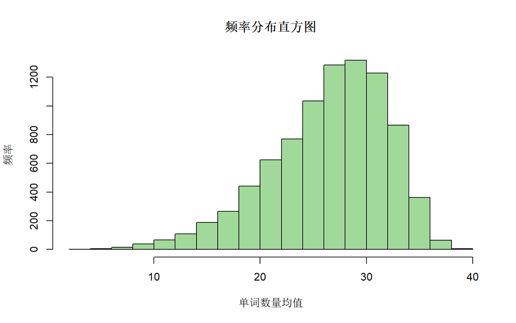

```r
for(i in 1:8675){
  a <- post1[[i]]%>%str_count(boundary("word"))
  a <- a[a>0]
  data$senlengh[i] <- mean(a)
  data$senvar[i] <- var(a)
}
a <- post1[[775]]%>%str_count(boundary("word"))
hist(data$senlengh,col="#A1D99B",breaks=20,
     ylab = "频率",xlab = "单词数量均值",main = "频率分布直方图")
```

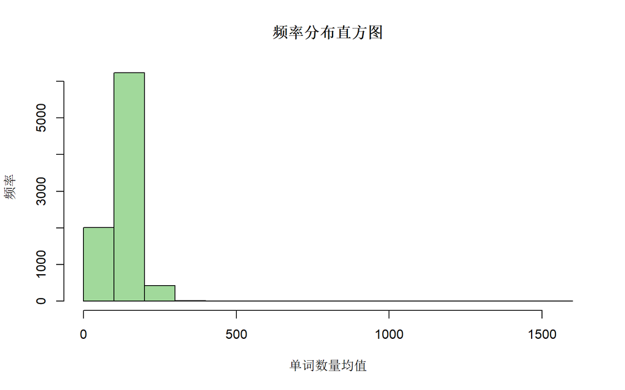

```r
hist(data$senvar,col="#A1D99B",breaks=20,
     ylab = "频率",xlab = "单词数量均值",main = "频率分布直方图")
```

## 标点数量

post2 将斜杠转化为了空格，并且依据空格进行分词

p1 一个一个的取

p2 去除网址连在一起

```r
post2 <- gsub("\\|+\\|\\|"," ",posts)
post2 <- strsplit(post2,split=" ",fixed = TRUE,useBytes = T)
for(i in 1:8675){
  p1 <- post2[[i]]
  p2 <- str_c(p1[!str_detect(p1,"http")],collapse = "")
  data$judian[i] <- str_count(p2,'\\.')
  data$douhao[i] <- str_count(p2,',')
  data$wenhao[i] <- str_count(p2,'\\?')
}
#write.csv(data,"yidwdw.csv") #以csv形式保存情感得分表
```

## 提取每个人发推内容词频分布与类平均词频分布间距离变量

这里对这一变量进行一些解释： 这里我们首先对两两相对立的类别（如E和I）分别统计了类别内部所有人的词频分布，通过绘制折线图可以比较出不同类别的人整体上在一些词语的使用频率上存在着差异。因而我们可以分别统计每个人单独的使用词语的词频分布，并计算该词频到两个类别整体词频分布的差异（差值绝对值向量求和，或者说一范数），以此作为判断每个人属于哪种类别的一个依据（变量）。

### 一个不同类别整体词频差异的示例

```r
mbti <- read.csv("mbti.csv",fileEncoding='GBK',stringsAsFactors = F)
tail(mbti)
```

|  | type | EI | NS | FT | JP | posts |
| --- | --- | --- | --- | --- | --- | --- |
| 8670 | INFJ | I | N | FALSE | J | 'I'm not sure about a method for picking out INFJ musical artists, but I have another name to throw into the cauldron: Jon Crosby, singer songwriter for VAST. Additionally, he strikes me as 4w5 on...\… |
| 8671 | ISFP | I | S | FALSE | P | 'https://www.youtube.com/watch?v=t8edHB_h908\|\|\|IxFP just because I always think of cats as Fi doms for some reason. https://www.youtube.com/watch?v=ib28iGc9go4\|\|\|Especially on websites that have… |
| 8672 | ENFP | E | N | FALSE | P | 'So...if this thread already exists someplace else (which it does: http://personalitycafe.com/enfp-forum-inspirers/116902-movies-loved-enfp.html#post2952851), how the heck to I delete this one here???… |
| 8673 | INTP | I | N | TRUE | P | 'So many questions when i do these things. I would take the purple pill. Pick winning lottery numbers. Do whatever I want.\|\|\|I worked in a brewery for a couple years here. I dont know if you're fam… |
| 8674 | INFP | I | N | FALSE | P | 'I am very conflicted right now when it comes to wanting children. I honestly had no maternal instinct whatsoever until recently. Up until now, none of my close friends have had children, and I...\|\|… |
| 8675 | INFP | I | N | FALSE | P | 'It has been too long since I have been on personalitycafe - although it doesn't seem to have changed one bit - but I must say it is good to be back somewhere like this. Usually I turn to Doctor Who..… |

```r
type1 <- read.csv("mbti_type1.csv",fileEncoding='GBK',stringsAsFactors = F)
head(type1)
```

|  | word | E外向 | I内向 | prob_E | prob_I | dis |
| --- | --- | --- | --- | --- | --- | --- |
| 1 | actually | 1814 | 6095 | 0.04871499 | 0.04374193 | 0.004973062 |
| 2 | agree | 985 | 3148 | 0.02645218 | 0.02259222 | 0.003859964 |
| 3 | day | 988 | 4110 | 0.02653275 | 0.02949620 | 0.002963447 |
| 4 | few | 947 | 4199 | 0.02543169 | 0.03013492 | 0.004703227 |
| 5 | friend | 1309 | 4399 | 0.03515321 | 0.03157026 | 0.003582948 |
| 6 | friends | 1681 | 5211 | 0.04514327 | 0.03739773 | 0.007745539 |

```r
data <- as.data.frame(t(rep(0,dim(type1)[1])))
colnames(data) <- t(type1$word)
head(data)
```

|  | actually | agree | day | few | friend | friends | great | life | lol | love | make | mean | mind | myself | never | oh | still | thanks | thread | type | world | yeah | years |
| --- | --- | --- | --- | --- | --- | --- | --- | --- | --- | --- | --- | --- | --- | --- | --- | --- | --- | --- | --- | --- | --- | --- | --- |
| 1 | 0 | 0 | 0 | 0 | 0 | 0 | 0 | 0 | 0 | 0 | 0 | 0 | 0 | 0 | 0 | 0 | 0 | 0 | 0 | 0 | 0 | 0 | 0 |

```r
for (i in 1:dim(type1)[1]){
  x <- type1$word[i]
  a <- gsub((x),"#",mbti$posts)
  #b <- list(rep(0,dim(mbti)[1]))
  for (j in 1:dim(mbti)[1]){
    data[j,i] <- length(unlist(strsplit(a[j],split = '#')))
  }
  rm(x)
  rm(a)
}
head(data)
```

|  | actually | agree | day | few | friend | friends | great | life | lol | love | make | mean | mind | myself | never | oh | still | thanks | thread | type | world | yeah | years |
| --- | --- | --- | --- | --- | --- | --- | --- | --- | --- | --- | --- | --- | --- | --- | --- | --- | --- | --- | --- | --- | --- | --- | --- |
| 1 | 1 | 1 | 4 | 2 | 3 | 2 | 1 | 4 | 1 | 1 | 1 | 2 | 1 | 3 | 1 | 1 | 1 | 1 | 2 | 4 | 3 | 1 | 2 |
| 2 | 1 | 1 | 1 | 4 | 7 | 5 | 3 | 2 | 2 | 2 | 5 | 3 | 1 | 3 | 5 | 1 | 2 | 1 | 2 | 1 | 1 | 1 | 1 |
| 3 | 3 | 1 | 2 | 2 | 3 | 2 | 2 | 2 | 1 | 2 | 3 | 1 | 2 | 2 | 2 | 1 | 2 | 1 | 3 | 2 | 1 | 1 | 5 |
| 4 | 3 | 4 | 3 | 1 | 2 | 1 | 3 | 3 | 1 | 1 | 6 | 2 | 3 | 1 | 2 | 1 | 2 | 1 | 1 | 13 | 1 | 1 | 1 |
| 5 | 2 | 1 | 1 | 1 | 1 | 1 | 3 | 1 | 1 | 1 | 1 | 3 | 3 | 2 | 3 | 1 | 1 | 1 | 1 | 1 | 1 | 1 | 1 |
| 6 | 4 | 3 | 1 | 1 | 2 | 1 | 1 | 2 | 1 | 2 | 2 | 3 | 3 | 1 | 2 | 1 | 1 | 1 | 2 | 7 | 3 | 1 | 3 |

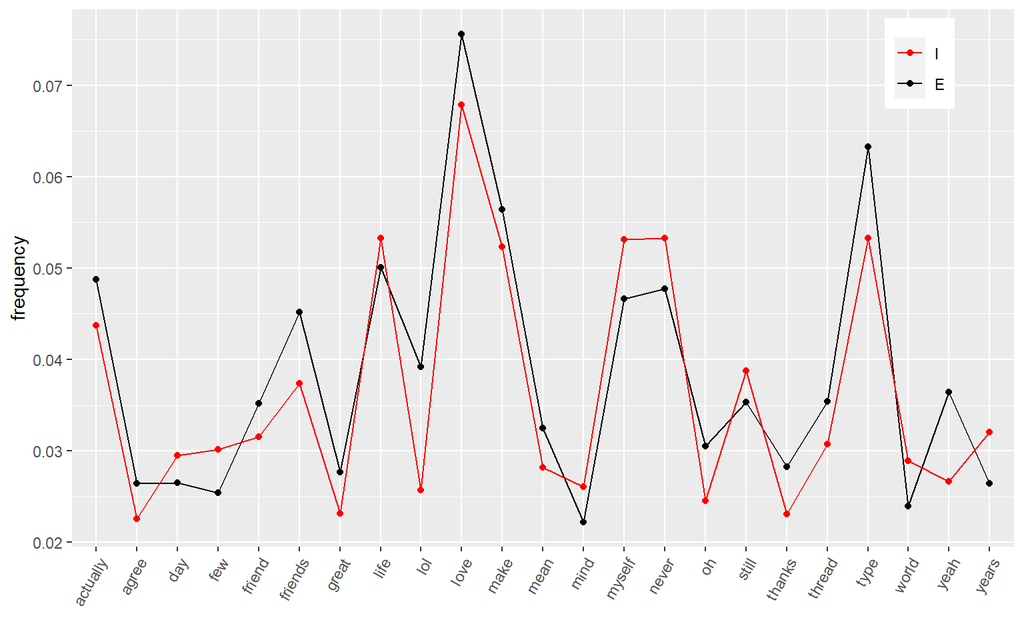

```r
library(ggplot2)
PROB_E <- type1$prob_E
PROB_I <- type1$prob_I
p3 <- ggplot()+
      geom_point(data=type1,aes(x=word,y=prob_E,group = 1,color = "black", shape = "B", linetype = "B"))+
      geom_line(data=type1,aes(x=word,y=prob_E,group = 1,color = "black", shape = "B", linetype = "B"))+
      geom_point(data=type1,aes(x=word,y=prob_I,group = 1,color = "red", shape = "A", linetype = "A"))+
      geom_line(data=type1,aes(x=word,y=prob_I,group = 1,color = "red", shape = "A", linetype = "A"))+
      scale_color_manual(name = "group",
                     values = c('red' = 'red', "black" = 'black'),
                     breaks = c("red", "black"),
                     labels = c('I', 'E')) +
     scale_shape_manual(name = "group",
                     values = c("A" = 16, "B" = 16),
                     labels = c('I', 'E')) +
      scale_linetype_manual(name = "group",
                          values = c("A" = 1, "B" = 1),
                          labels = c('I', 'E'))+
      xlab("")+
      ylab("frequency")+
      theme(plot.title = element_text(hjust = 0.5),
        axis.text.x=element_text(angle=60, hjust=1),
        legend.title=element_blank(),
        legend.position = c(0.9,0.9)
        )
p3
```

### EI

```r
#这部分前面绘图示例时已经统计过整体的词频了，所以这里直接计算距离
#初始化到两种类别的距离向量（和样本行数相同的维度）
dis_to_e <- c(rep(0,dim(data)[1]))
dis_to_i <- c(rep(0,dim(data)[1]))
for (i in 1:dim(data)[1]){
  temp <- c(rep(0,dim(data)[2]))
  sumn <- 0
  for (j in 1:dim(data)[2]){
    temp[j] <- data[i,j]
    sumn <- sumn + temp[j]
  }
  #temp为单个样本的特征词词频分布向量
  temp <- temp/c(rep(sumn,dim(data)[2]))
  #计算到两个类别的距离
  dis_to_e[i] <- sum(abs(temp-PROB_E))
  dis_to_i[i] <- sum(abs(temp-PROB_I))

}
#将结果存为数据框
data_need <- data.frame(mbti$EI,PROBtoE=dis_to_e,PROBtoI=dis_to_i)
```

```r
#重命名并导出为csv文件
colnames(data_need) <- c("class","disE","disI")
head(data_need)
```

|  | class | disE | disI |
| --- | --- | --- | --- |
| 1 | I | 0.5080837 | 0.4631809 |
| 2 | E | 0.5283948 | 0.5228180 |
| 3 | I | 0.3803206 | 0.3458416 |
| 4 | I | 0.5809130 | 0.5834777 |
| 5 | E | 0.4533752 | 0.4131216 |
| 6 | I | 0.5068950 | 0.4916104 |

```r
#write.table(data_need,"dis1.csv",row.names=FALSE,col.names=TRUE,sep=",")
```

### NS

```r
#读入第二种分类维度的特征词词频数据
type2 <- read.csv("mbti_type2.csv",fileEncoding='GBK',stringsAsFactors = F)
head(type2)
```

|  | word | N直觉 | S感觉 | prob_N | prob_S | dis |
| --- | --- | --- | --- | --- | --- | --- |
| 1 | anything | 4577 | 800 | 0.02844465 | 0.03320742 | 0.004762773 |
| 2 | back | 4735 | 795 | 0.02942657 | 0.03299987 | 0.003573305 |
| 3 | doing | 3558 | 651 | 0.02211188 | 0.02702254 | 0.004910663 |
| 4 | everyone | 3960 | 505 | 0.02461018 | 0.02096219 | 0.003647998 |
| 5 | find | 7346 | 1046 | 0.04565313 | 0.04341870 | 0.002234429 |
| 6 | first | 6669 | 936 | 0.04144579 | 0.03885268 | 0.002593103 |

```r
PROB_N <- type2$prob_N
PROB_S <- type2$prob_S
#data是用来存放记录每个样本特征词词频的数据框
data <- as.data.frame(t(rep(0,dim(type2)[1])))
colnames(data) <- t(type2$word)
head(data)
```

|  | anything | back | doing | everyone | find | first | life | lol | love | make | many | oh | over | pretty | school | sometimes | sure | thanks | though | through | type | usually | work | yeah | yes |
| --- | --- | --- | --- | --- | --- | --- | --- | --- | --- | --- | --- | --- | --- | --- | --- | --- | --- | --- | --- | --- | --- | --- | --- | --- | --- |
| 1 | 0 | 0 | 0 | 0 | 0 | 0 | 0 | 0 | 0 | 0 | 0 | 0 | 0 | 0 | 0 | 0 | 0 | 0 | 0 | 0 | 0 | 0 | 0 | 0 | 0 |

```r
#用循环统计每个样本的特征词词频
for (i in 1:dim(type2)[1]){
  x <- type2$word[i]
  a <- gsub((x),"#",mbti$posts)
  #b <- list(rep(0,dim(mbti)[1]))
  for (j in 1:dim(mbti)[1]){
    data[j,i] <- length(unlist(strsplit(a[j],split = '#')))
  }
  rm(x)
  rm(a)
}
head(data)
```

|  | anything | back | doing | everyone | find | first | life | lol | love | make | many | oh | over | pretty | school | sometimes | sure | thanks | though | through | type | usually | work | yeah | yes |
| --- | --- | --- | --- | --- | --- | --- | --- | --- | --- | --- | --- | --- | --- | --- | --- | --- | --- | --- | --- | --- | --- | --- | --- | --- | --- |
| 1 | 1 | 3 | 1 | 3 | 1 | 1 | 4 | 1 | 1 | 1 | 2 | 1 | 4 | 1 | 2 | 1 | 2 | 1 | 2 | 1 | 4 | 1 | 2 | 1 | 1 |
| 2 | 2 | 5 | 1 | 1 | 3 | 4 | 2 | 2 | 2 | 5 | 2 | 1 | 6 | 2 | 1 | 2 | 2 | 1 | 4 | 2 | 1 | 1 | 4 | 1 | 1 |
| 3 | 1 | 2 | 2 | 2 | 3 | 2 | 2 | 1 | 2 | 3 | 1 | 1 | 2 | 1 | 1 | 3 | 1 | 1 | 3 | 1 | 2 | 1 | 5 | 1 | 2 |
| 4 | 3 | 1 | 1 | 3 | 2 | 1 | 3 | 1 | 1 | 6 | 3 | 1 | 4 | 3 | 1 | 1 | 3 | 1 | 6 | 2 | 13 | 1 | 2 | 1 | 1 |
| 5 | 2 | 2 | 4 | 1 | 1 | 1 | 1 | 1 | 1 | 1 | 2 | 1 | 6 | 1 | 1 | 1 | 2 | 1 | 4 | 1 | 1 | 1 | 2 | 1 | 1 |
| 6 | 2 | 2 | 1 | 3 | 3 | 1 | 2 | 1 | 2 | 2 | 4 | 1 | 4 | 2 | 2 | 1 | 1 | 1 | 9 | 4 | 7 | 2 | 3 | 1 | 1 |

```r
#初始化到两种类别的距离向量（和样本行数相同的维度）
dis_to_n <- c(rep(0,dim(data)[1]))
dis_to_s <- c(rep(0,dim(data)[1]))
for (i in 1:dim(data)[1]){
  temp <- c(rep(0,dim(data)[2]))
  sumn <- 0
  for (j in 1:dim(data)[2]){
    temp[j] <- data[i,j]
    sumn <- sumn + temp[j]
  }
  #temp为单个样本的特征词词频分布向量
  temp <- temp/c(rep(sumn,dim(data)[2]))
  #计算到两个类别的距离
  dis_to_n[i] <- sum(abs(temp-PROB_N))
  dis_to_s[i] <- sum(abs(temp-PROB_S))

}
#将结果存为数据框
data_need <- data.frame(mbti$NS,PROBtoN=dis_to_n,PROBtoS=dis_to_s)
```

```r
#重命名并导出为csv文件
colnames(data_need) <- c("class","disN","disS")
head(data_need)
```

|  | class | disN | disS |
| --- | --- | --- | --- |
| 1 | N | 0.4587432 | 0.4597703 |
| 2 | N | 0.4423745 | 0.4771778 |
| 3 | N | 0.3432329 | 0.3879060 |
| 4 | N | 0.5561661 | 0.5485049 |
| 5 | N | 0.5258433 | 0.5316346 |
| 6 | N | 0.5354926 | 0.5128900 |

```r
#write.table(data_need,"dis2.csv",row.names=FALSE,col.names=TRUE,sep=",")
```

### FT

```r
#读入第三种分类维度的特征词词频数据
type3 <- read.csv("mbti_type3.csv",fileEncoding='GBK',stringsAsFactors = F)
head(type3)
```

|  | word | F情感 | T思维 | prob_F | prob_T | dis |
| --- | --- | --- | --- | --- | --- | --- |
| 1 | actually | 4351 | 3558 | 0.03708850 | 0.04233950 | 0.005251004 |
| 2 | always | 5993 | 3940 | 0.05108512 | 0.04688523 | 0.004199896 |
| 3 | anything | 2876 | 2501 | 0.02451540 | 0.02976141 | 0.005246006 |
| 4 | didn | 2739 | 2420 | 0.02334760 | 0.02879753 | 0.005449928 |
| 5 | doesn | 2660 | 2515 | 0.02267419 | 0.02992801 | 0.007253816 |
| 6 | find | 4610 | 3782 | 0.03929625 | 0.04500506 | 0.005708810 |

```r
PROB_F <- type3$prob_F
PROB_T <- type3$prob_T
#data是用来存放记录每个样本特征词词频的数据框
data <- as.data.frame(t(rep(0,dim(type2)[1])))
colnames(data) <- t(type2$word)
head(data)
```

|  | anything | back | doing | everyone | find | first | life | lol | love | make | many | oh | over | pretty | school | sometimes | sure | thanks | though | through | type | usually | work | yeah | yes |
| --- | --- | --- | --- | --- | --- | --- | --- | --- | --- | --- | --- | --- | --- | --- | --- | --- | --- | --- | --- | --- | --- | --- | --- | --- | --- |
| 1 | 0 | 0 | 0 | 0 | 0 | 0 | 0 | 0 | 0 | 0 | 0 | 0 | 0 | 0 | 0 | 0 | 0 | 0 | 0 | 0 | 0 | 0 | 0 | 0 | 0 |

```r
#用循环统计每个样本的特征词词频
for (i in 1:dim(type2)[1]){
  x <- type2$word[i]
  a <- gsub((x),"#",mbti$posts)
  #b <- list(rep(0,dim(mbti)[1]))
  for (j in 1:dim(mbti)[1]){
    data[j,i] <- length(unlist(strsplit(a[j],split = '#')))
  }
  rm(x)
  rm(a)
}
head(data)
```

|  | anything | back | doing | everyone | find | first | life | lol | love | make | many | oh | over | pretty | school | sometimes | sure | thanks | though | through | type | usually | work | yeah | yes |
| --- | --- | --- | --- | --- | --- | --- | --- | --- | --- | --- | --- | --- | --- | --- | --- | --- | --- | --- | --- | --- | --- | --- | --- | --- | --- |
| 1 | 1 | 3 | 1 | 3 | 1 | 1 | 4 | 1 | 1 | 1 | 2 | 1 | 4 | 1 | 2 | 1 | 2 | 1 | 2 | 1 | 4 | 1 | 2 | 1 | 1 |
| 2 | 2 | 5 | 1 | 1 | 3 | 4 | 2 | 2 | 2 | 5 | 2 | 1 | 6 | 2 | 1 | 2 | 2 | 1 | 4 | 2 | 1 | 1 | 4 | 1 | 1 |
| 3 | 1 | 2 | 2 | 2 | 3 | 2 | 2 | 1 | 2 | 3 | 1 | 1 | 2 | 1 | 1 | 3 | 1 | 1 | 3 | 1 | 2 | 1 | 5 | 1 | 2 |
| 4 | 3 | 1 | 1 | 3 | 2 | 1 | 3 | 1 | 1 | 6 | 3 | 1 | 4 | 3 | 1 | 1 | 3 | 1 | 6 | 2 | 13 | 1 | 2 | 1 | 1 |
| 5 | 2 | 2 | 4 | 1 | 1 | 1 | 1 | 1 | 1 | 1 | 2 | 1 | 6 | 1 | 1 | 1 | 2 | 1 | 4 | 1 | 1 | 1 | 2 | 1 | 1 |
| 6 | 2 | 2 | 1 | 3 | 3 | 1 | 2 | 1 | 2 | 2 | 4 | 1 | 4 | 2 | 2 | 1 | 1 | 1 | 9 | 4 | 7 | 2 | 3 | 1 | 1 |

```r
#初始化到两种类别的距离向量（和样本行数相同的维度）
dis_to_f <- c(rep(0,dim(data)[1]))
dis_to_t <- c(rep(0,dim(data)[1]))

for (i in 1:dim(data)[1]){
  temp <- c(rep(0,dim(data)[2]))
  sumn <- 0
  for (j in 1:dim(data)[2]){
    temp[j] <- data[i,j]
    sumn <- sumn + temp[j]
  }
  #temp为单个样本的特征词词频分布向量
  temp <- temp/c(rep(sumn,dim(data)[2]))
  #计算到两个类别的距离
  dis_to_f[i] <- sum(abs(temp-PROB_F))
  dis_to_t[i] <- sum(abs(temp-PROB_T))

}
#将结果存为数据框
data_need <- data.frame(mbti$FT,PROBtoF=dis_to_f,PROBtoT=dis_to_t)
```

```r
#重命名并导出为csv文件
colnames(data_need) <- c("class","disF","disT")
head(data_need)
```

|  | class | disF | disT |
| --- | --- | --- | --- |
| 1 | FALSE | 0.4763162 | 0.5321703 |
| 2 | TRUE | 0.4426558 | 0.5198741 |
| 3 | TRUE | 0.5003399 | 0.4489698 |
| 4 | TRUE | 0.6534266 | 0.6653803 |
| 5 | TRUE | 0.4831582 | 0.5144488 |
| 6 | TRUE | 0.6137936 | 0.6416455 |

```r
#write.table(data_need,"dis3.csv",row.names=FALSE,col.names=TRUE,sep=",")
```

### JP

```r
#读入第三种分类维度的特征词词频数据
type4 <- read.csv("mbti_type4.csv",fileEncoding='GBK',stringsAsFactors = F)
head(type4)
```

|  | word | J判断 | P知觉 | prob_J | prob_P | dis |
| --- | --- | --- | --- | --- | --- | --- |
| 1 | actually | 2870 | 5039 | 0.04036398 | 0.04503691 | 0.004672934 |
| 2 | anything | 1987 | 3390 | 0.02794538 | 0.03029870 | 0.002353322 |
| 3 | doesn | 2087 | 3088 | 0.02935178 | 0.02759952 | 0.001752264 |
| 4 | down | 1527 | 2639 | 0.02147589 | 0.02358651 | 0.002110621 |
| 5 | find | 3360 | 5032 | 0.04725539 | 0.04497435 | 0.002281041 |
| 6 | friends | 2494 | 4398 | 0.03507588 | 0.03930787 | 0.004231991 |

```r
PROB_J <- type4$prob_J
PROB_P <- type4$prob_P
#data是用来存放记录每个样本特征词词频的数据框
data <- as.data.frame(t(rep(0,dim(type4)[1])))
colnames(data) <- t(type4$word)
head(data)
```

|  | actually | anything | doesn | down | find | friends | lol | lot | love | never | oh | others | person | post | pretty | probably | right | school | though | type | understand | yeah | yes |
| --- | --- | --- | --- | --- | --- | --- | --- | --- | --- | --- | --- | --- | --- | --- | --- | --- | --- | --- | --- | --- | --- | --- | --- |
| 1 | 0 | 0 | 0 | 0 | 0 | 0 | 0 | 0 | 0 | 0 | 0 | 0 | 0 | 0 | 0 | 0 | 0 | 0 | 0 | 0 | 0 | 0 | 0 |

```r
#用循环统计每个样本的特征词词频
for (i in 1:dim(type4)[1]){
  x <- type4$word[i]
  a <- gsub((x),"#",mbti$posts)
  #b <- list(rep(0,dim(mbti)[1]))
  for (j in 1:dim(mbti)[1]){
    data[j,i] <- length(unlist(strsplit(a[j],split = '#')))
  }
  rm(x)
  rm(a)
}
head(data)
```

|  | actually | anything | doesn | down | find | friends | lol | lot | love | never | oh | others | person | post | pretty | probably | right | school | though | type | understand | yeah | yes |
| --- | --- | --- | --- | --- | --- | --- | --- | --- | --- | --- | --- | --- | --- | --- | --- | --- | --- | --- | --- | --- | --- | --- | --- |
| 1 | 1 | 1 | 1 | 2 | 1 | 2 | 1 | 1 | 1 | 1 | 1 | 1 | 4 | 2 | 1 | 1 | 2 | 2 | 2 | 4 | 1 | 1 | 1 |
| 2 | 1 | 2 | 2 | 2 | 3 | 5 | 2 | 1 | 2 | 5 | 1 | 1 | 4 | 4 | 2 | 1 | 3 | 1 | 4 | 1 | 1 | 1 | 1 |
| 3 | 3 | 1 | 1 | 2 | 3 | 2 | 1 | 1 | 2 | 2 | 1 | 1 | 1 | 4 | 1 | 1 | 5 | 1 | 3 | 2 | 2 | 1 | 2 |
| 4 | 3 | 3 | 3 | 1 | 2 | 1 | 1 | 4 | 1 | 2 | 1 | 3 | 2 | 4 | 3 | 2 | 2 | 1 | 6 | 13 | 1 | 1 | 1 |
| 5 | 2 | 2 | 3 | 3 | 1 | 1 | 1 | 1 | 1 | 3 | 1 | 3 | 2 | 2 | 1 | 2 | 1 | 1 | 4 | 1 | 2 | 1 | 1 |
| 6 | 4 | 2 | 3 | 1 | 3 | 1 | 1 | 5 | 2 | 2 | 1 | 1 | 4 | 5 | 2 | 2 | 2 | 2 | 9 | 7 | 5 | 1 | 1 |

```r
#初始化到两种类别的距离向量（和样本行数相同的维度）
dis_to_j <- c(rep(0,dim(data)[1]))
dis_to_p <- c(rep(0,dim(data)[1]))

for (i in 1:dim(data)[1]){
  temp <- c(rep(0,dim(data)[2]))
  sumn <- 0
  for (j in 1:dim(data)[2]){
    temp[j] <- data[i,j]
    sumn <- sumn + temp[j]
  }
  #temp为单个样本的特征词词频分布向量
  temp <- temp/c(rep(sumn,dim(data)[2]))
  #计算到两个类别的距离
  dis_to_j[i] <- sum(abs(temp-PROB_J))
  dis_to_p[i] <- sum(abs(temp-PROB_P))

}
#将结果存为数据框
data_need <- data.frame(mbti$JP,PROBtoJ=dis_to_j,PROBtoP=dis_to_p)

#重命名并导出为csv文件
colnames(data_need) <- c("class","disJ","disP")
head(data_need)
```

|  | class | disJ | disP |
| --- | --- | --- | --- |
| 1 | J | 0.4172213 | 0.4480019 |
| 2 | P | 0.4891434 | 0.4975050 |
| 3 | P | 0.3997054 | 0.4098457 |
| 4 | J | 0.5249542 | 0.5388031 |
| 5 | J | 0.5064575 | 0.5194636 |
| 6 | J | 0.4869492 | 0.5159337 |

```r
#write.table(data_need,"dis4.csv",row.names=FALSE,col.names=TRUE,sep=",")
```

## 情感得分均值、方差

```r
data <- read.csv("mbti_new.csv", encoding = "UTF-8", stringsAsFactors = FALSE)
posts<-data$post_new
posts <- posts %>%
  replace_white() %>% replace_contraction()
#textclean包的replace_white和replace_contraction函数, 可以将"I'll"等缩写词展开

# posts去除数字之后的留言
posts<-gsub("\\d","",data$post_new)
# post将所有的|||(及更多)替换成#之后的留言
post<-gsub("\\|+\\|\\|"," # ",posts)
post<-str_to_lower(post)
# post1 切分之后的留言(list)
post1<-strsplit(post,split="#",fixed=TRUE,useBytes=T)

length<-c()
for(i in 1:length(post)){
  length[i]<-length(post1[[i]])
} #每条post的总评论数

start<-1
for(i in 2:length(length)){
  start[i]<-start[i-1]+length[i-1]
} #句子序号首位
end<-start[2:length(start)]-1
end[length(end)+1]<-end[length(end)]+rev(length)[1] #句子序号末位
all<-do.call(c,post1) #全部句子
motion_score0<-c()

for(i in 1:length(all)){
  motion_score0[i]<-get_motionscore(all[i])
} #求每个句子各自的情感得分(规避"haha"后), 总运行时长约75分钟, 慎运行
##对于调整"ha", "haha","hahaha","hahahah"词的必要性:
#####对于all[start[7770]+39], 其不处理"haha"值时, 情感得分271(情感得分虚高), 作用get_motionscore函数时为12

#write.table(motion_score0,file="motion_score0.txt",row.names=F,col.names=F,sep=" ") #保存向量结果

motion_mean<-c();motion_var<-c();motion_range<-c()
for(i in 1:length(post)){
  motion<-motion_score0[start[i]:end[i]]
  motion_mean[i]<-mean(motion)
  motion_var[i]<-var(motion)
} #求每一个记录的情感得分均值、方差
```

## 网站数量

```r
num_http<-str_count(post,"http") #统计包含http字符的数量
http<-as.data.frame(cbind(as.character(data$type),num_http));colnames(http)<-c("type","num") #转化为数据框
head(http) #展示前六行
http$num<-as.numeric(http$num) #将第二列转为数值型
ddply(http,.(type),function(x){mean(x$num)})#统计不同人格的转发网站数均值
data$num_http<-num_http
dat0$num_http<-num_http
dot<-read.csv("yidwdw.csv") #读取yidwdw.csv中已经得到的标点统计结果
dat0<-cbind(dat0,dot[7:10])
#保存结果
#write.xlsx(dat0,"motion_score.xlsx")
```

# 变量可视化

## 因变量

### EI

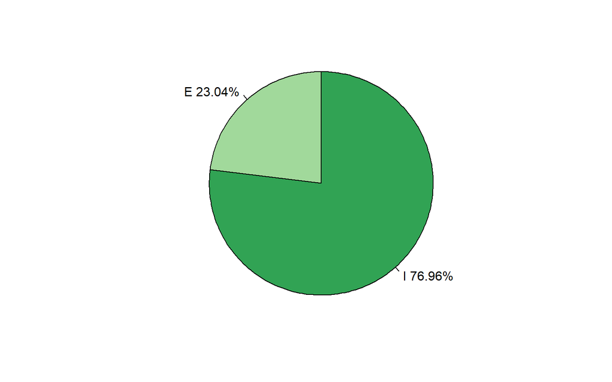

```r
dot<-read.csv("yidwdw.csv") #读取yidwdw.csv中已经得到的统计结果
count1 <- table(dot$EI)
name1 <- names(count1)
percent <- round(prop.table(count1)*100,2)
label1 <- paste(name1,' ',percent,'%',sep='')
pie(count1,labels = label1,init.angle = 90,radius=1,col=c("#A1D99B","#31A354"))
```

### FT

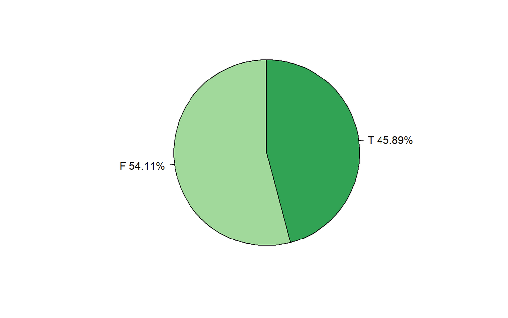

```r
count1 <- table(dot$FT)
name1 <- c("F","T")
percent <- round(prop.table(count1)*100,2)
label1 <- paste(name1,' ',percent,'%',sep='')
pie(count1,labels = label1,init.angle = 90,radius=1,col=c("#A1D99B","#31A354"))
```

### NS

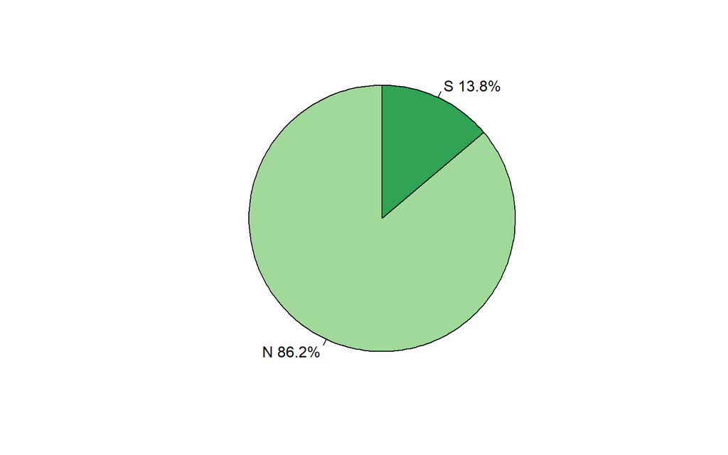

```r
count1 <- table(dot$NS)
name1 <- names(count1)
percent <- round(prop.table(count1)*100,2)
label1 <- paste(name1,' ',percent,'%',sep='')
pie(count1,labels = label1,init.angle = 90,radius=1,col=c("#A1D99B","#31A354"))
```

### JP

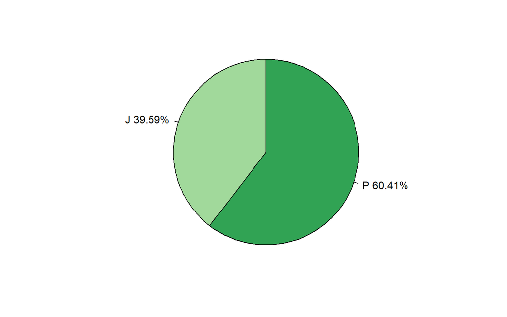

```r
count1 <- table(dot$JP)
name1 <- names(count1)
percent <- round(prop.table(count1)*100,2)
label1 <- paste(name1,' ',percent,'%',sep='')
pie(count1,labels = label1,init.angle = 90,radius=1,col=c("#A1D99B","#31A354"))
```

## 情感得分均值

### EI

```r
#合并变量
dat0<-read.xlsx("motion_score.xlsx")
```

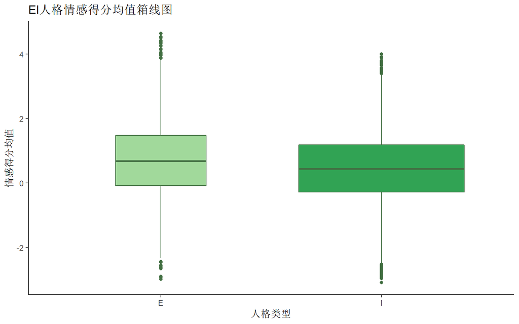

```r
intervel<-ddply(dat0,.(EI),c(function(x){mean(x$motion_mean)-3*sd(x$motion_mean)},function(x){mean(x$motion_mean)+3*sd(x$motion_mean)})) #根据3σ原则得到一个区间, 区间外的值去掉, 后续同理
dat1<-rbind(dat0[dat0$EI=='E' & intervel[1,2]<dat0$motion_mean & dat0$motion_mean<intervel[1,3],c(3,7)],dat0[dat0$EI=='I' & intervel[2,2]<dat0$motion_mean & dat0$motion_mean<intervel[2,3],c(3,7)])

mytheme<-theme(plot.title=element_text(size="15",hjust="0.5"),panel.border=element_blank(),panel.grid.major=element_blank(),panel.grid.minor=element_blank(),axis.line=element_line(color="black")) #设置画图主题
#去离群值, 后续同理
p<-ggplot(dat1,aes(x=EI,y=motion_mean))
p+geom_boxplot(fill=c("#A1D99B","#31A354"),col="#426F42",varwidth=T)+labs(x="人格类型",y="情感得分均值")+mytheme+ggtitle("EI人格情感得分均值箱线图")+scale_fill_brewer(palette="Greens")+theme_classic() #情感得分箱线图
```

### NS

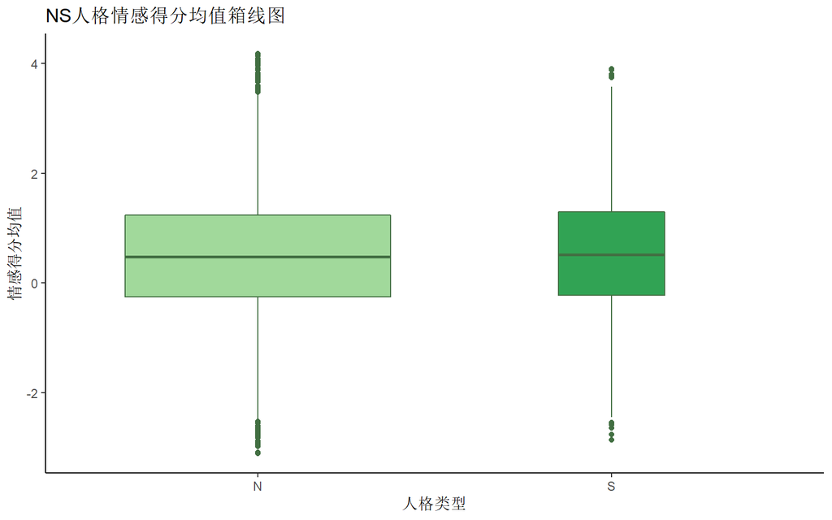

```r
intervel<-ddply(dat0,.(NS),c(function(x){mean(x$motion_mean)-3*sd(x$motion_mean)},function(x){mean(x$motion_mean)+3*sd(x$motion_mean)}))
dat1<-rbind(dat0[dat0$NS=='N' & intervel[1,2]<dat0$motion_mean & dat0$motion_mean<intervel[1,3],c(4,7)],dat0[dat0$NS=='S' & intervel[2,2]<dat0$motion_mean & dat0$motion_mean<intervel[2,3],c(4,7)])
p<-ggplot(dat1,aes(x=NS,y=motion_mean))
p+geom_boxplot(fill=c("#A1D99B","#31A354"),col="#426F42",varwidth=T)+labs(x="人格类型",y="情感得分均值")+mytheme+ggtitle("NS人格情感得分均值箱线图")+scale_fill_brewer(palette="Greens")+theme_classic() #情感得分箱线图
```

### FT

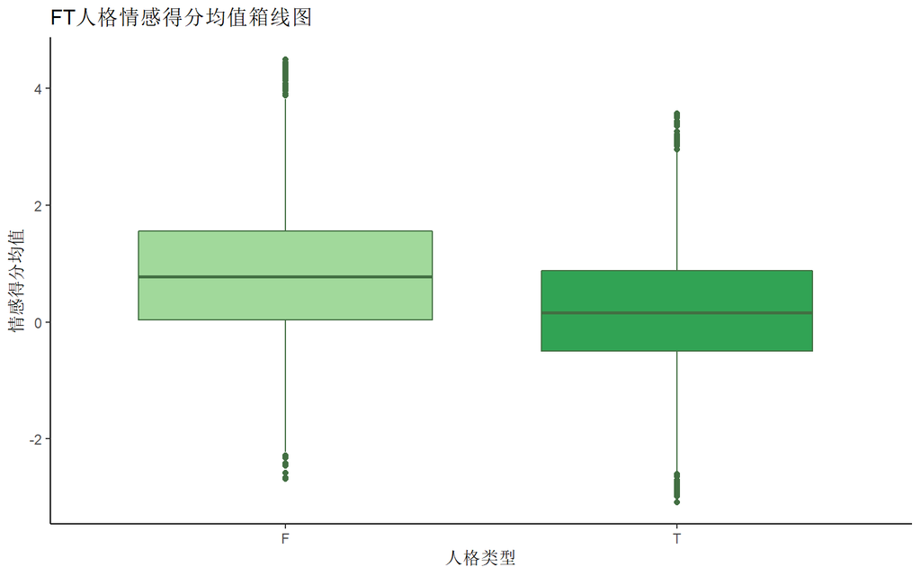

```r
intervel<-ddply(dat0,.(FT),c(function(x){mean(x$motion_mean)-3*sd(x$motion_mean)},function(x){mean(x$motion_mean)+3*sd(x$motion_mean)}))
dat1<-rbind(dat0[dat0$FT=='F' & intervel[1,2]<dat0$motion_mean & dat0$motion_mean<intervel[1,3],c(5,7)],dat0[dat0$FT=='T' & intervel[2,2]<dat0$motion_mean & dat0$motion_mean<intervel[2,3],c(5,7)])
p<-ggplot(dat1,aes(x=FT,y=motion_mean))
p+geom_boxplot(fill=c("#A1D99B","#31A354"),col="#426F42",varwidth=T)+labs(x="人格类型",y="情感得分均值")+mytheme+ggtitle("FT人格情感得分均值箱线图")+scale_fill_brewer(palette="Greens")+theme_classic() #情感得分箱线图
```

### JP

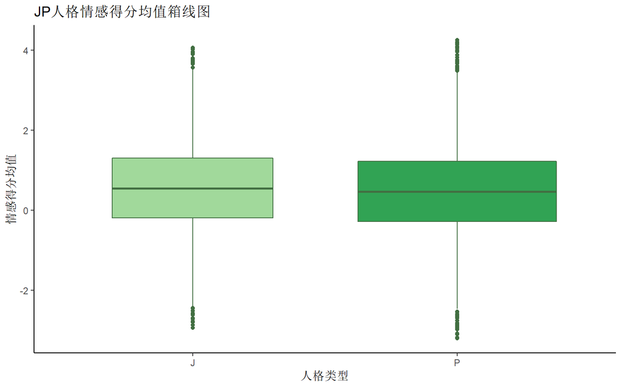

```r
intervel<-ddply(dat0,.(JP),c(function(x){mean(x$motion_mean)-3*sd(x$motion_mean)},function(x){mean(x$motion_mean)+3*sd(x$motion_mean)}))
dat1<-rbind(dat0[dat0$JP=='J' & intervel[1,2]<dat0$motion_mean & dat0$motion_mean<intervel[1,3],c(6,7)],dat0[dat0$JP=='P' & intervel[2,2]<dat0$motion_mean & dat0$motion_mean<intervel[2,3],c(6,7)])
p<-ggplot(dat1,aes(x=JP,y=motion_mean))
p+geom_boxplot(fill=c("#A1D99B","#31A354"),col="#426F42",varwidth=T)+labs(x="人格类型",y="情感得分均值")+mytheme+ggtitle("JP人格情感得分均值箱线图")+scale_fill_brewer(palette="Greens")+theme_classic() #情感得分箱线图
```

## 情感得分方差

### EI

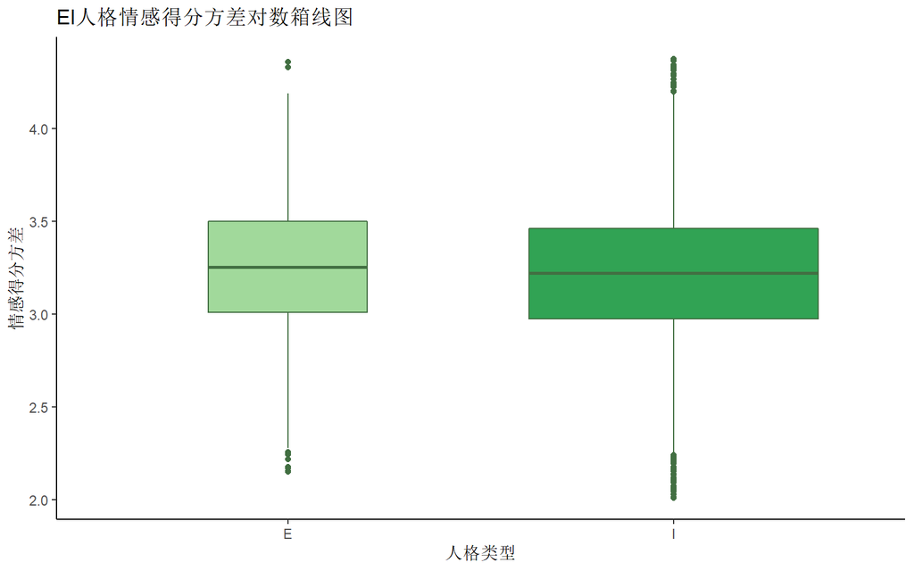

```r
intervel<-ddply(dat0,.(EI),c(function(x){mean(log(x$motion_var+1))-3*sd(log(x$motion_var+1))},function(x){mean(log(x$motion_var+1))+3*sd(log(x$motion_var+1))}))
dat1<-rbind(dat0[dat0$EI=='E' & intervel[1,2]<log(dat0$motion_var+1) & log(dat0$motion_var+1)<intervel[1,3],c(3,8)],dat0[dat0$EI=='I' & intervel[2,2]<log(dat0$motion_var+1) & log(dat0$motion_var+1)<intervel[2,3],c(3,8)])
p<-ggplot(dat1,aes(x=EI,y=log(motion_var+1)))
p+geom_boxplot(fill=c("#A1D99B","#31A354"),col="#426F42",varwidth=T)+labs(x="人格类型",y="情感得分方差")+mytheme+ggtitle("EI人格情感得分方差对数箱线图")+scale_fill_brewer(palette="Greens")+theme_classic() #情感得分箱线图
```

### NS

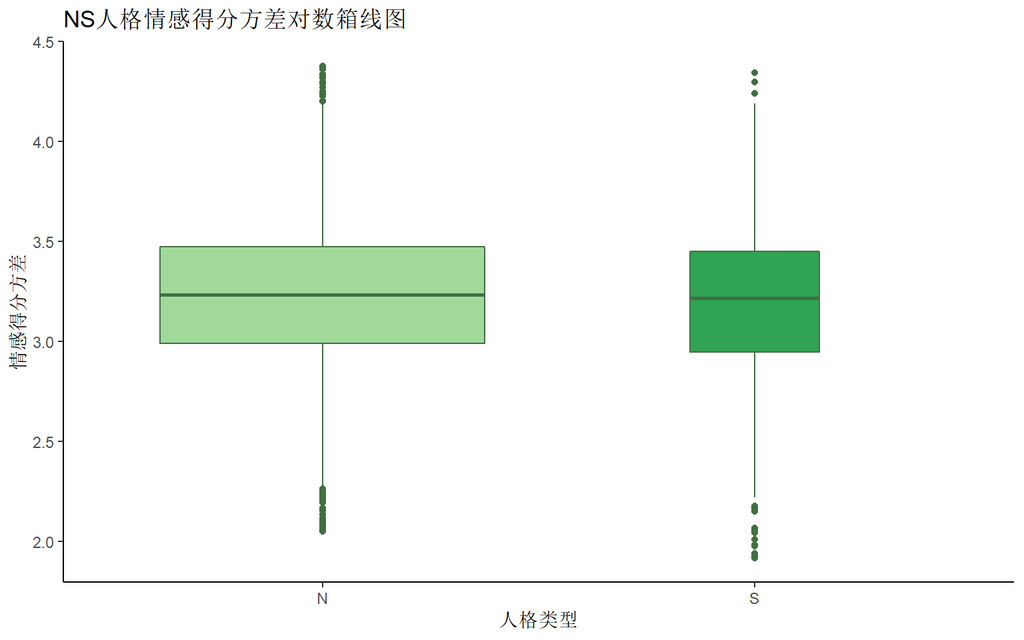

```r
intervel<-ddply(dat0,.(NS),c(function(x){mean(log(x$motion_var+1))-3*sd(log(x$motion_var+1))},function(x){mean(log(x$motion_var+1))+3*sd(log(x$motion_var+1))}))
dat1<-rbind(dat0[dat0$NS=='N' & intervel[1,2]<log(dat0$motion_var+1) & log(dat0$motion_var+1)<intervel[1,3],c(4,8)],dat0[dat0$NS=='S' & intervel[2,2]<log(dat0$motion_var+1) & log(dat0$motion_var+1)<intervel[2,3],c(4,8)])
p<-ggplot(dat1,aes(x=NS,y=log(motion_var+1)))
p+geom_boxplot(fill=c("#A1D99B","#31A354"),col="#426F42",varwidth=T)+labs(x="人格类型",y="情感得分方差")+mytheme+ggtitle("NS人格情感得分方差对数箱线图")+scale_fill_brewer(palette="Greens")+theme_classic() #情感得分箱线图
```

### FT

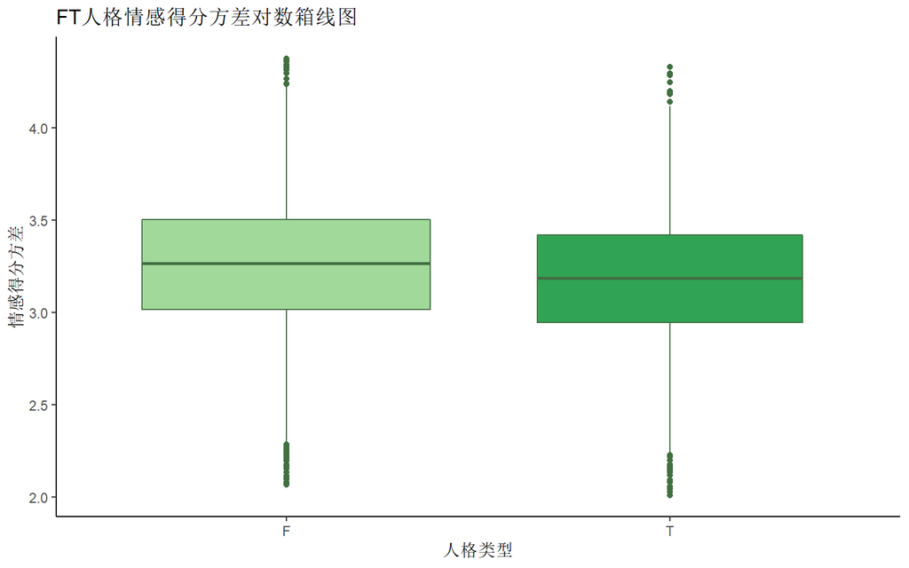

```r
intervel<-ddply(dat0,.(FT),c(function(x){mean(log(x$motion_var+1))-3*sd(log(x$motion_var+1))},function(x){mean(log(x$motion_var+1))+3*sd(log(x$motion_var+1))}))
dat1<-rbind(dat0[dat0$FT=='F' & intervel[1,2]<log(dat0$motion_var+1) & log(dat0$motion_var+1)<intervel[1,3],c(5,8)],dat0[dat0$FT=='T' & intervel[2,2]<log(dat0$motion_var+1) & log(dat0$motion_var+1)<intervel[2,3],c(5,8)])
p<-ggplot(dat1,aes(x=FT,y=log(motion_var+1)))
p+geom_boxplot(fill=c("#A1D99B","#31A354"),col="#426F42",varwidth=T)+labs(x="人格类型",y="情感得分方差")+mytheme+ggtitle("FT人格情感得分方差对数箱线图")+scale_fill_brewer(palette="Greens")+theme_classic() #情感得分箱线图
```

### JP

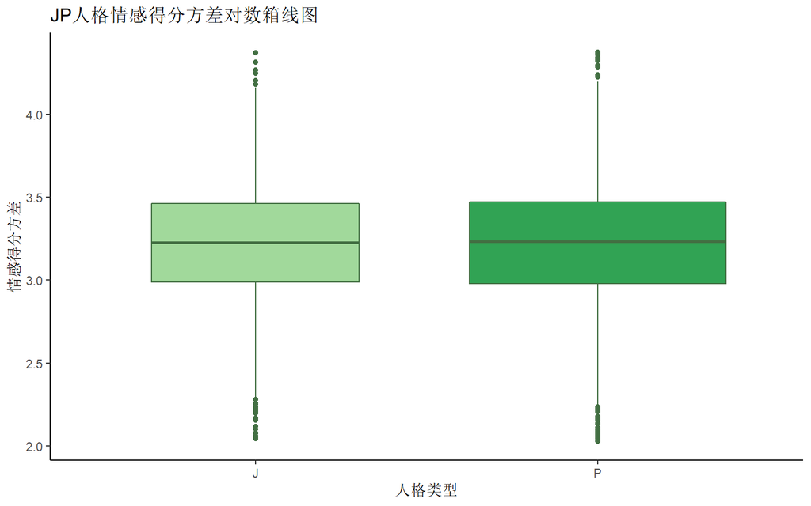

```r
intervel<-ddply(dat0,.(JP),c(function(x){mean(log(x$motion_var+1))-3*sd(log(x$motion_var+1))},function(x){mean(log(x$motion_var+1))+3*sd(log(x$motion_var+1))}))
dat1<-rbind(dat0[dat0$JP=='J' & intervel[1,2]<log(dat0$motion_var+1) & log(dat0$motion_var+1)<intervel[1,3],c(6,8)],dat0[dat0$JP=='P' & intervel[2,2]<log(dat0$motion_var+1) & log(dat0$motion_var+1)<intervel[2,3],c(6,8)])
p<-ggplot(dat1,aes(x=JP,y=log(motion_var+1)))
p+geom_boxplot(fill=c("#A1D99B","#31A354"),col="#426F42",varwidth=T)+labs(x="人格类型",y="情感得分方差")+mytheme+ggtitle("JP人格情感得分方差对数箱线图")+scale_fill_brewer(palette="Greens")+theme_classic() #情感得分箱线图
```

## 网站数量

### EI

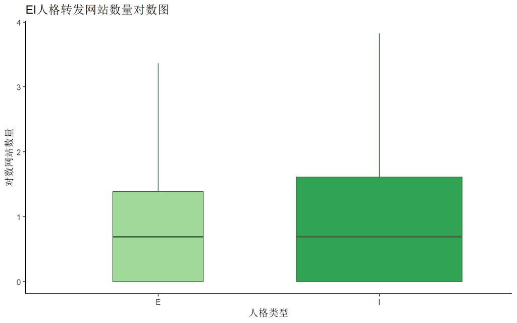

```r
intervel<-ddply(dat0,.(EI),c(function(x){mean(log(x$num_http+1))-3*sd(log(x$num_http+1))},function(x){mean(log(x$num_http+1))+3*sd(log(x$num_http+1))}))
dat1<-rbind(dat0[dat0$EI=='E' & intervel[1,2]<log(dat0$num_http+1) & log(dat0$num_http+1)<intervel[1,3],c(3,10)],dat0[dat0$EI=='I' & intervel[2,2]<log(dat0$num_http+1) & log(dat0$num_http+1)<intervel[2,3],c(3,10)])
p<-ggplot(dat1,aes(x=EI,y=log(num_http+1)))
p+geom_boxplot(fill=c("#A1D99B","#31A354"),col="#426F42",varwidth=T)+labs(x="人格类型",y="对数网站数量")+mytheme+ggtitle("EI人格转发网站数量对数图")+scale_fill_brewer(palette="Greens")+theme_classic()
```

### NS

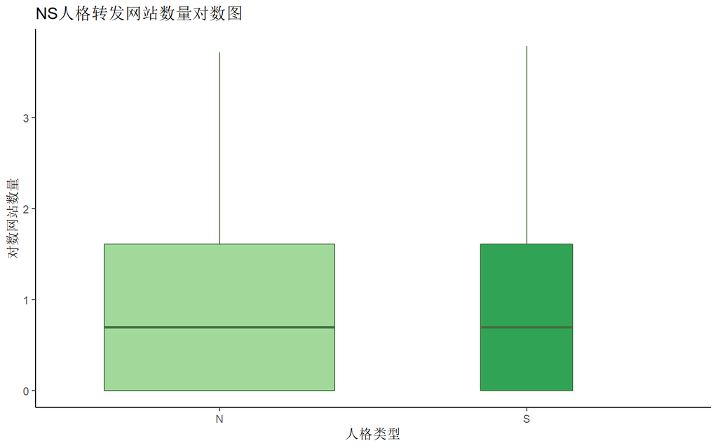

```r
intervel<-ddply(dat0,.(NS),c(function(x){mean(log(x$num_http+1))-3*sd(log(x$num_http+1))},function(x){mean(log(x$num_http+1))+3*sd(log(x$num_http+1))}))
dat1<-rbind(dat0[dat0$NS=='N' & intervel[1,2]<log(dat0$num_http+1) & log(dat0$num_http+1)<intervel[1,3],c(4,10)],dat0[dat0$NS=='S' & intervel[2,2]<log(dat0$num_http+1) & log(dat0$num_http+1)<intervel[2,3],c(4,10)])
p<-ggplot(dat1,aes(x=NS,y=log(num_http+1)))
p+geom_boxplot(fill=c("#A1D99B","#31A354"),col="#426F42",varwidth=T)+labs(x="人格类型",y="对数网站数量")+mytheme+ggtitle("NS人格转发网站数量对数图")+scale_fill_brewer(palette="Greens")+theme_classic()
```

### FT

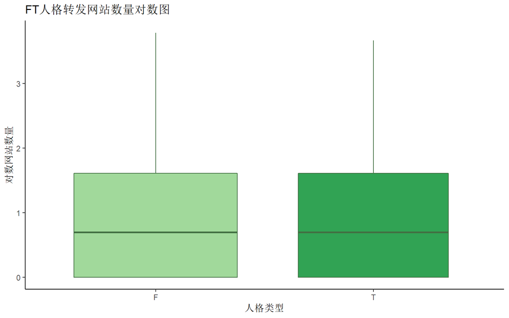

```r
intervel<-ddply(dat0,.(FT),c(function(x){mean(log(x$num_http+1))-3*sd(log(x$num_http+1))},function(x){mean(log(x$num_http+1))+3*sd(log(x$num_http+1))}))
dat1<-rbind(dat0[dat0$FT=='F' & intervel[1,2]<log(dat0$num_http+1) & log(dat0$num_http+1)<intervel[1,3],c(5,10)],dat0[dat0$FT=='T' & intervel[2,2]<log(dat0$num_http+1) & log(dat0$num_http+1)<intervel[2,3],c(5,10)])
p<-ggplot(dat1,aes(x=FT,y=log(num_http+1)))
p+geom_boxplot(fill=c("#A1D99B","#31A354"),col="#426F42",varwidth=T)+labs(x="人格类型",y="对数网站数量")+mytheme+ggtitle("FT人格转发网站数量对数图")+scale_fill_brewer(palette="Greens")+theme_classic()
```

### JP

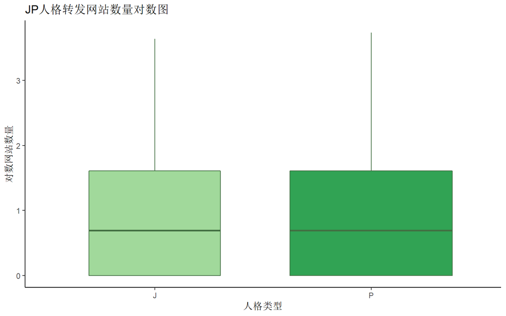

```r
intervel<-ddply(dat0,.(JP),c(function(x){mean(log(x$num_http+1))-3*sd(log(x$num_http+1))},function(x){mean(log(x$num_http+1))+3*sd(log(x$num_http+1))}))
dat1<-rbind(dat0[dat0$JP=='J' & intervel[1,2]<log(dat0$num_http+1) & log(dat0$num_http+1)<intervel[1,3],c(6,10)],dat0[dat0$JP=='P' & intervel[2,2]<log(dat0$num_http+1) & log(dat0$num_http+1)<intervel[2,3],c(6,10)])
p<-ggplot(dat1,aes(x=JP,y=log(num_http+1)))
p+geom_boxplot(fill=c("#A1D99B","#31A354"),col="#426F42",varwidth=T)+labs(x="人格类型",y="对数网站数量")+mytheme+ggtitle("JP人格转发网站数量对数图")+scale_fill_brewer(palette="Greens")+theme_classic()
```

## 单词词数均值

### EI

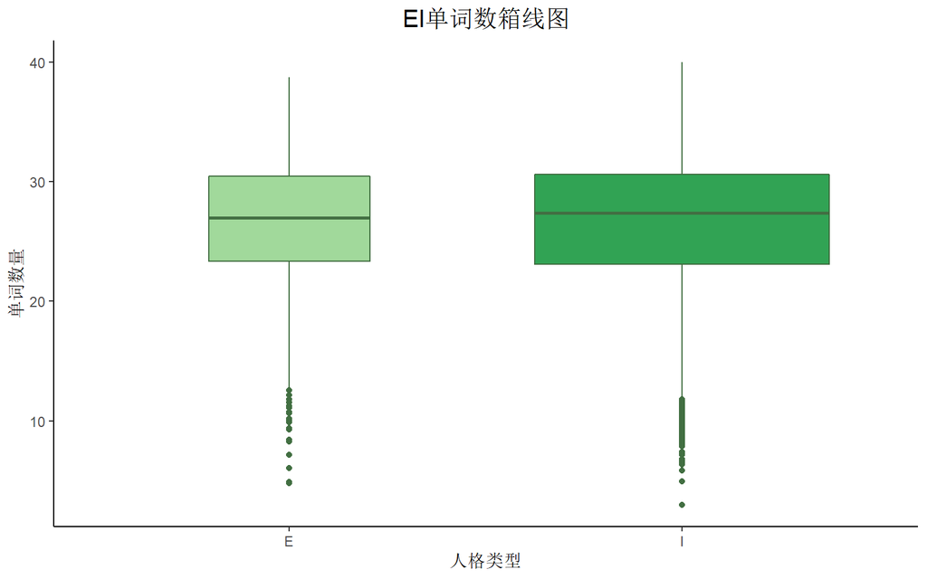

```r
data <- read.csv("yidwdw.csv")#读入之前保存的结果
p<-ggplot(data,aes(x=EI,y=senlengh))
mytheme <- theme(plot.title=element_text(size="15",hjust="0.5"),panel.border = element_blank(),panel.grid.major = element_blank(), panel.grid.minor = element_blank(),axis.line = element_line(colour = "black"))
p+geom_boxplot(fill=c("#A1D99B","#31A354"),col="#426F42",varwidth=T)+scale_fill_brewer(palette="Greens")+labs(x="人格类型",y="单词数量")+ theme_classic()+ggtitle("EI单词数箱线图")+mytheme
```

### NS

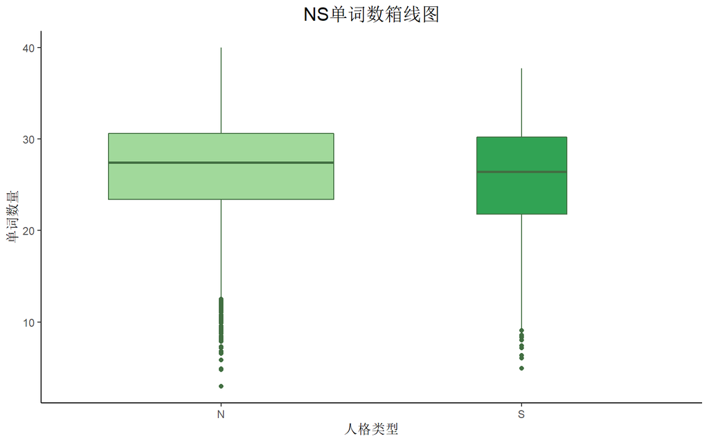

```r
p<-ggplot(data,aes(x=NS,y=senlengh))
p+geom_boxplot(fill=c("#A1D99B","#31A354"),col="#426F42",varwidth=T)+scale_fill_brewer(palette="Greens")+labs(x="人格类型",y="单词数量")+ theme_classic()+ggtitle("NS单词数箱线图")+mytheme
```

### FT

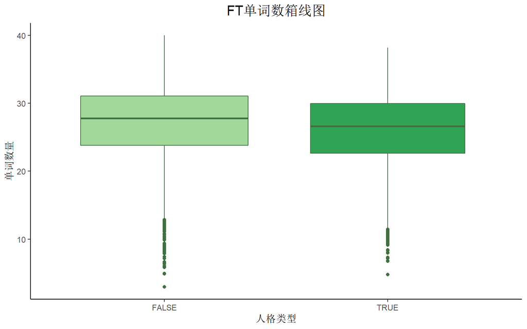

```r
p<-ggplot(data,aes(x=FT,y=senlengh))
p+geom_boxplot(fill=c("#A1D99B","#31A354"),col="#426F42",varwidth=T)+scale_fill_brewer(palette="Greens")+labs(x="人格类型",y="单词数量")+ theme_classic()+ggtitle("FT单词数箱线图")+mytheme
```

### JP

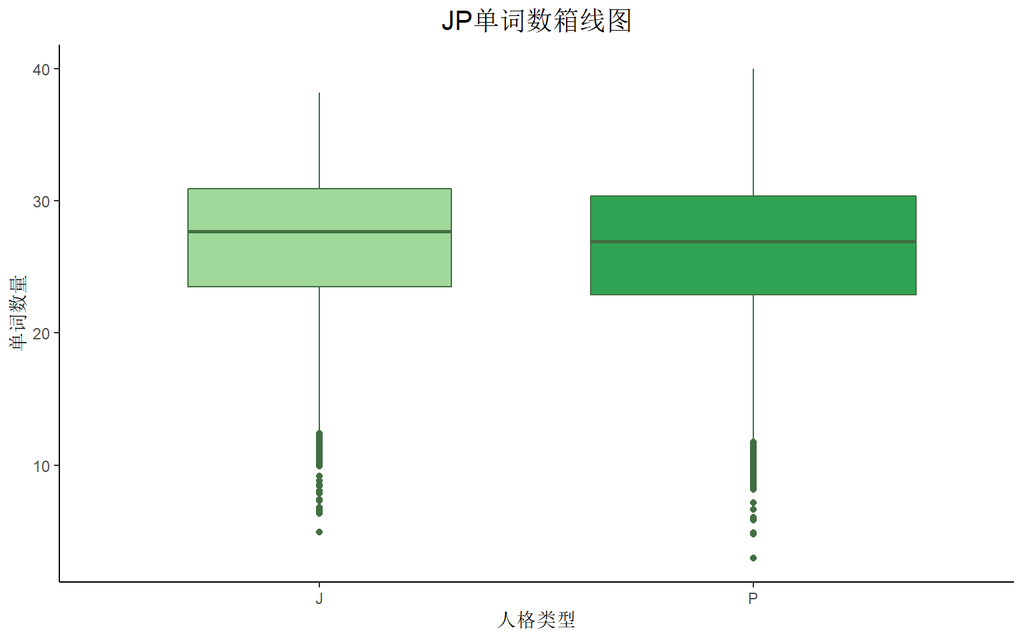

```r
p<-ggplot(data,aes(x=JP,y=senlengh))
p+geom_boxplot(fill=c("#A1D99B","#31A354"),col="#426F42",varwidth=T)+scale_fill_brewer(palette="Greens")+labs(x="人格类型",y="单词数量")+ theme_classic()+ggtitle("JP单词数箱线图")+mytheme
```

## 单词词数方差

### EI

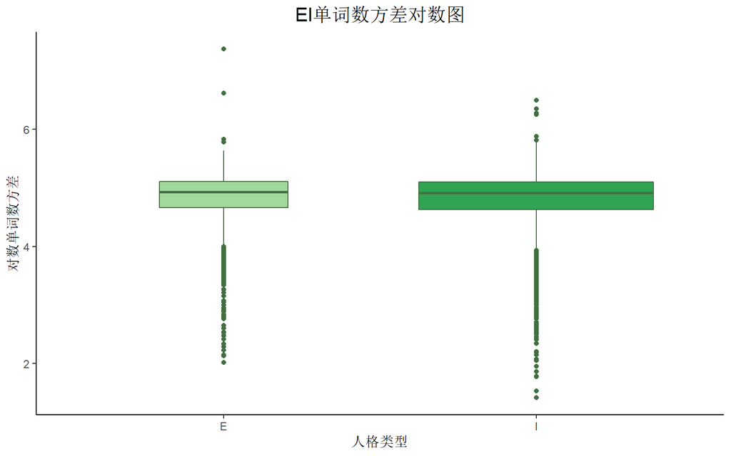

```r
p<-ggplot(data,aes(x=EI,y=log(senvar)))
p+geom_boxplot(fill=c("#A1D99B","#31A354"),col="#426F42",varwidth=T)+scale_fill_brewer(palette="Greens")+labs(x="人格类型",y="对数单词数方差")+ theme_classic()+ggtitle("EI单词数方差对数图")+mytheme
```

### NS

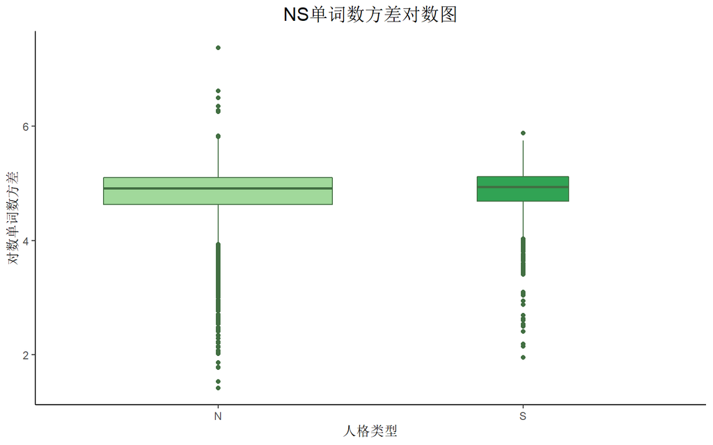

```r
p<-ggplot(data,aes(x=NS,y=log(senvar)))
p+geom_boxplot(fill=c("#A1D99B","#31A354"),col="#426F42",varwidth=T)+scale_fill_brewer(palette="Greens")+labs(x="人格类型",y="对数单词数方差")+ theme_classic()+ggtitle("NS单词数方差对数图")+mytheme
```

### FT

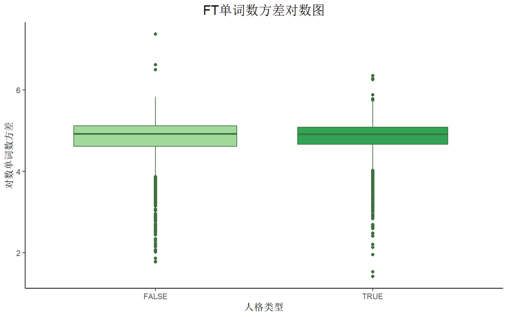

```r
p<-ggplot(data,aes(x=FT,y=log(senvar)))
p+geom_boxplot(fill=c("#A1D99B","#31A354"),col="#426F42",varwidth=T)+scale_fill_brewer(palette="Greens")+labs(x="人格类型",y="对数单词数方差")+ theme_classic()+ggtitle("FT单词数方差对数图")+mytheme
```

### JP

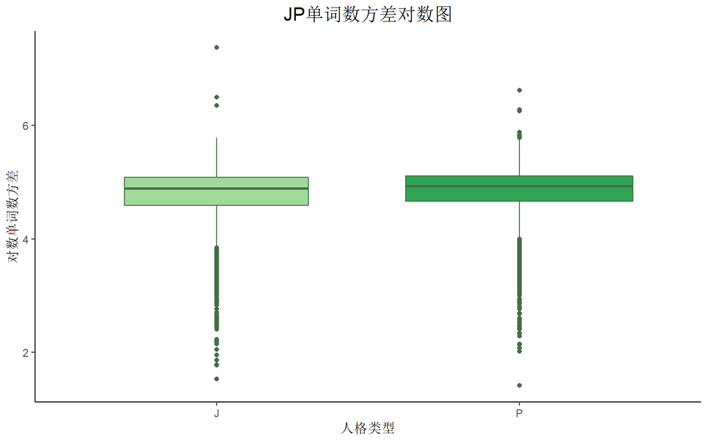

```r
p<-ggplot(data,aes(x=JP,y=log(senvar)))
p+geom_boxplot(fill=c("#A1D99B","#31A354"),col="#426F42",varwidth=T)+scale_fill_brewer(palette="Greens")+labs(x="人格类型",y="对数单词数方差")+ theme_classic()+ggtitle("JP单词数方差对数图")+mytheme
```

## 句点数量

### EI

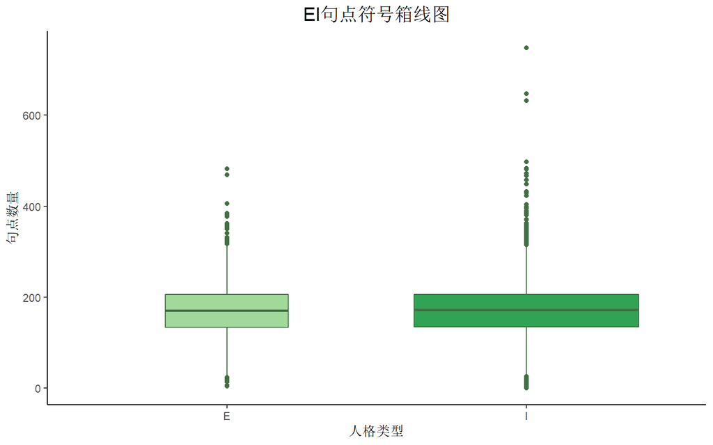

```r
p<-ggplot(data,aes(x=EI,y=judian))
p+geom_boxplot(fill=c("#A1D99B","#31A354"),col="#426F42",varwidth=T)+scale_fill_brewer(palette="Greens")+labs(x="人格类型",y="句点数量")+ theme_classic()+ggtitle("EI句点符号箱线图")+mytheme
```

### NS

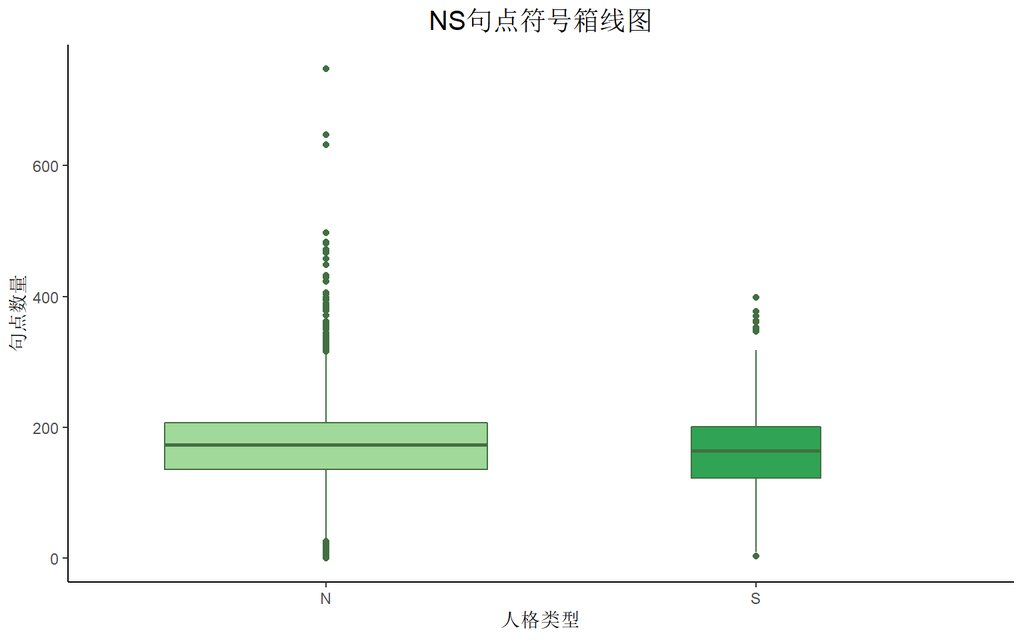

```r
p<-ggplot(data,aes(x=NS,y=judian))
p+geom_boxplot(fill=c("#A1D99B","#31A354"),col="#426F42",varwidth=T)+scale_fill_brewer(palette="Greens")+labs(x="人格类型",y="句点数量")+ theme_classic()+ggtitle("NS句点符号箱线图")+mytheme
```

### FT

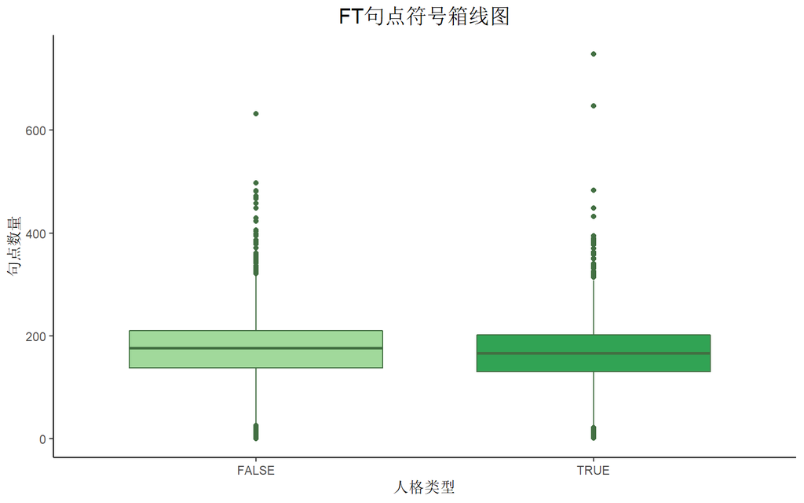

```r
p<-ggplot(data,aes(x=FT,y=judian))
mytheme <- theme(plot.title=element_text(size="15",hjust="0.5"),panel.border = element_blank(),panel.grid.major = element_blank(), panel.grid.minor = element_blank(),axis.line = element_line(colour = "black"))
#mytheme<-theme(plot.title=element_text(size="10",hjust="0.5"),legend.position="none")
p+geom_boxplot(fill=c("#A1D99B","#31A354"),col="#426F42",varwidth=T)+scale_fill_brewer(palette="Greens")+labs(x="人格类型",y="句点数量")+ theme_classic()+ggtitle("FT句点符号箱线图")+mytheme
```

### JP

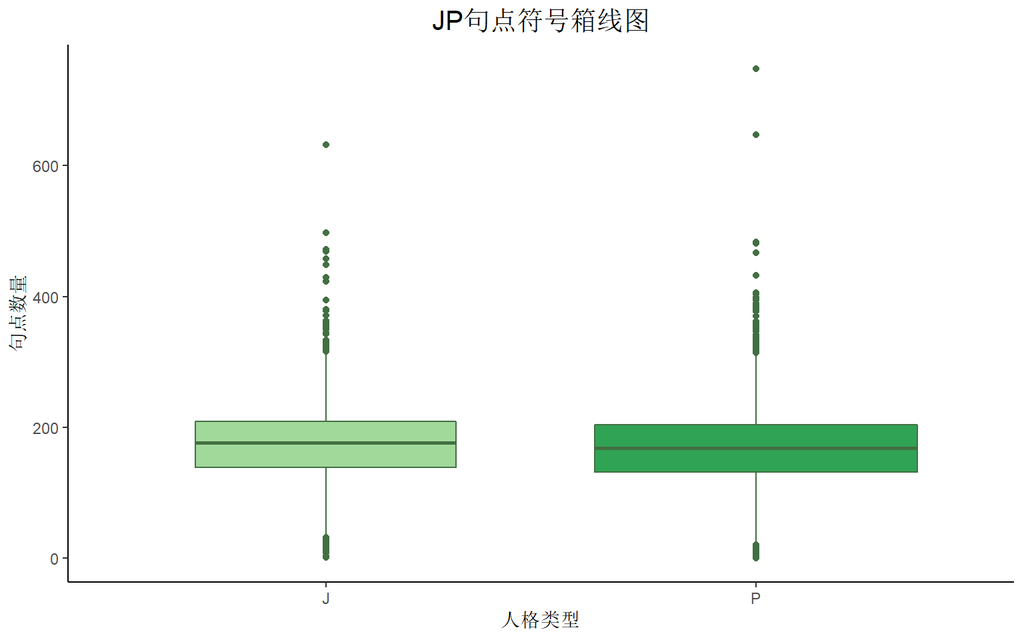

```r
p<-ggplot(data,aes(x=JP,y=judian))
p+geom_boxplot(fill=c("#A1D99B","#31A354"),col="#426F42",varwidth=T)+scale_fill_brewer(palette="Greens")+labs(x="人格类型",y="句点数量")+theme_classic()+ggtitle("JP句点符号箱线图")+mytheme
```